# Les Bieds : analyse des gas 2023

2024-02-19

## Introduction

Campagne de mesures : 31.05.2023 - 1.11.2023, 7 mesures

Terrain effectué par Alicia Frésard (aliciafresard_ecobio@protonmail.com), assistée par Julie Boserup (julie.boserup@lineco.ch)

## Site

[figure not shown]

[figure not shown]

Les points de mesures ont été sélectionnés de manière à évaluer les émissions de gaz dans toutes les environnements présents.

*2073:* bas marais à prairie humide, drains désactivés. Fauché Juin *2517:* prairie. Fauchée Août, Septembre, *2215:* prairie de fauche. Purinée et fauchée Juin *HM:* haut marais (15= lande, 16=betulaie sur tourbe) *PL:* maraîchage, tourbe nue, plantes présents en septembre. Sous bâche en novembre

## Overview du site global

### Commentaires données gas acquises

on est dans la majorité des cas aux alentours de 2000 nmol mol-1(ppb) CH4 et aux alentours de 500 µmol mol-1 (ppm) CO2.Les seuls endroit ou le ch4 est bine plus haut sont en 10 11 12, mais semble être des erreurs -> A VERIFIER

### CO2 respiration, toutes les placettes:

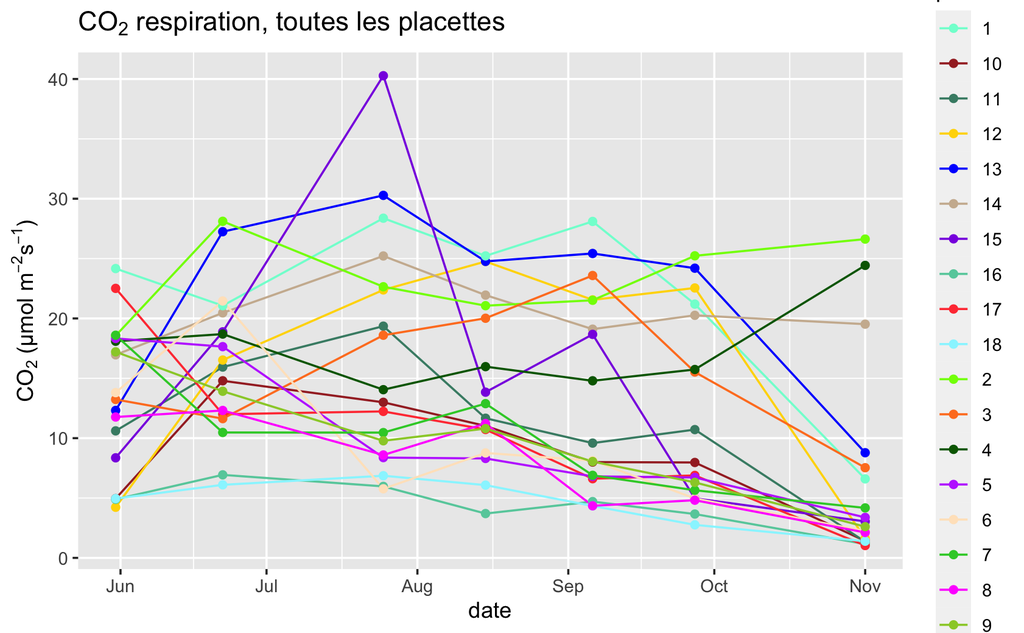

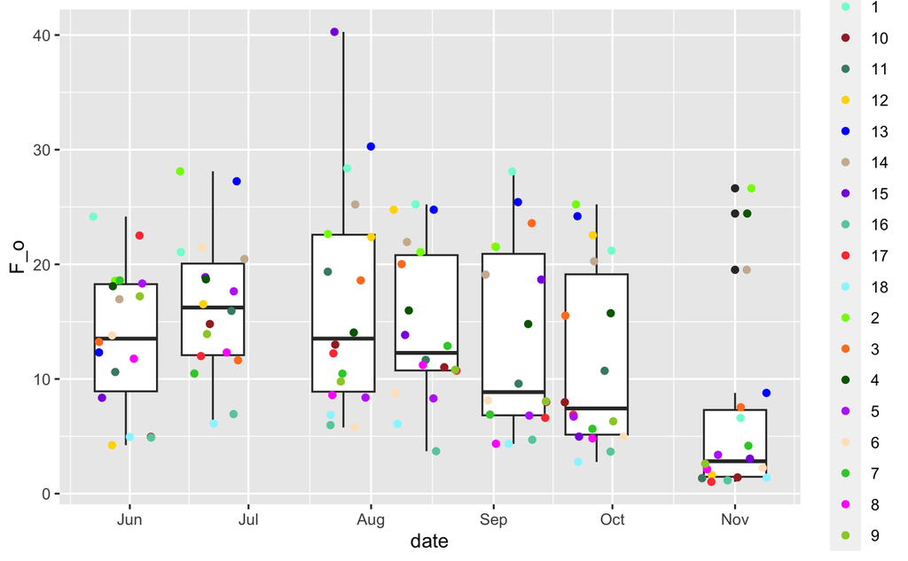

à part une diminution des flux en novembre, la tendance à la hausse en été n’est pas frappante

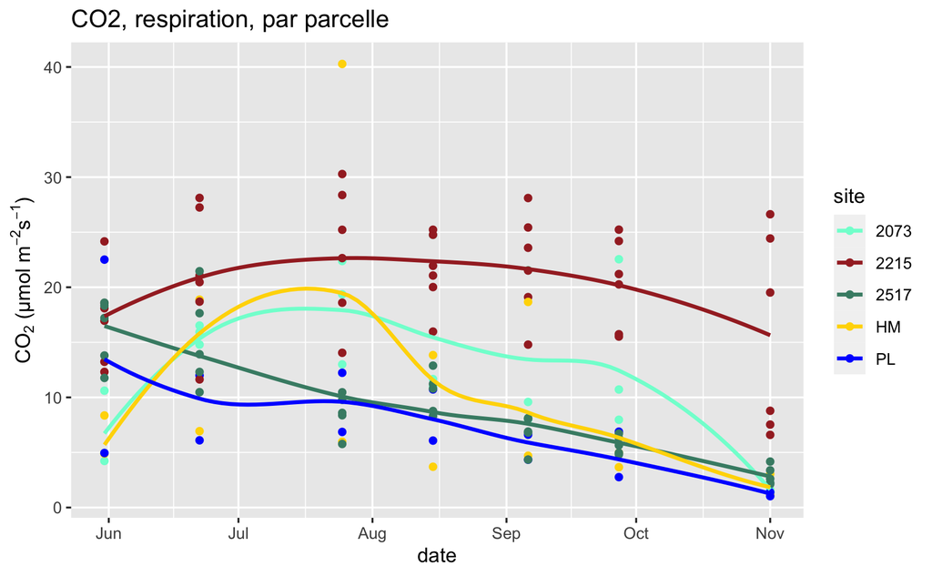

- La parcelle 2215, toujours drainée, emet plus de CO2 que les autres.
- 2073 et le haut marais montrent une varaition saisonnière plus importante, probablement dû aux fluctuation de la nappe permises par l’absence de drains.Le pic de CO2 est dans le plot de land haut marais. Peut être du à une sécheresse importante de la tourbe, qui se décompose
- 2517 ancien lit du ruisseau émettent moins et en décroissance pendant la saison
- La parcelle de maraîchage émet mois que les autres

### CO2 NEE, toutes les placettes

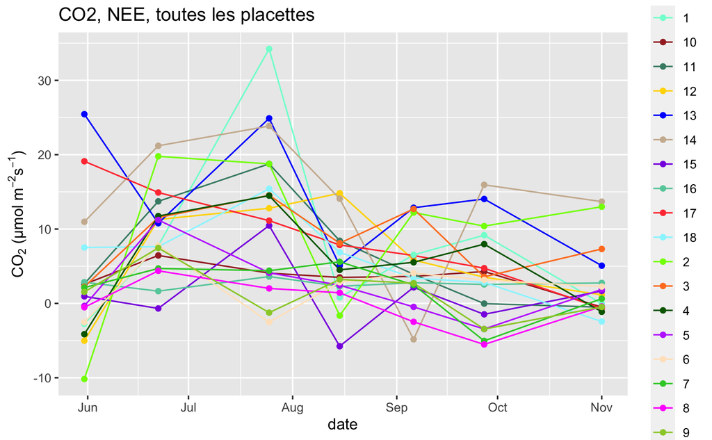

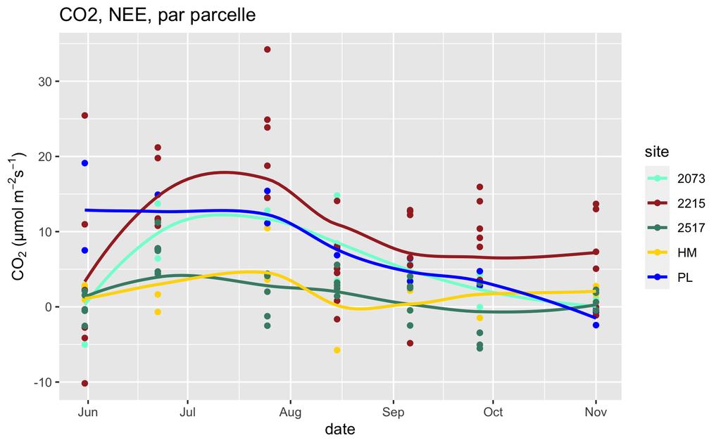

ATTENTION: la lumière jouant un rôle majeur dans l’efficacité de la photosynthèse, les comparaisons d’un jour à l’autre sont à faire avec prudence. Il est plus sûr de comparer les différents sites sur un même journée.

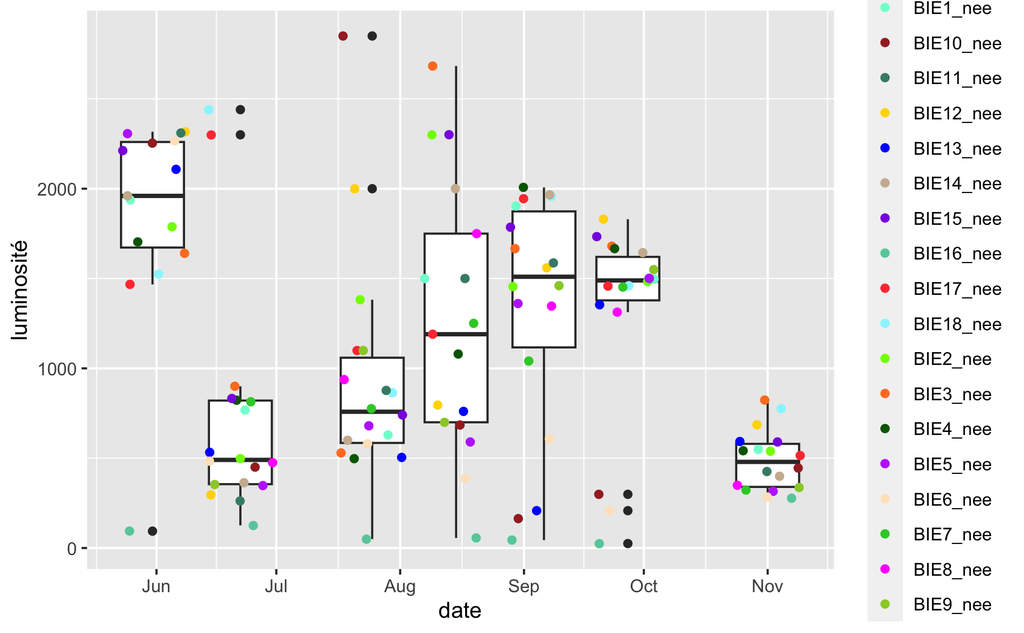

## Methane

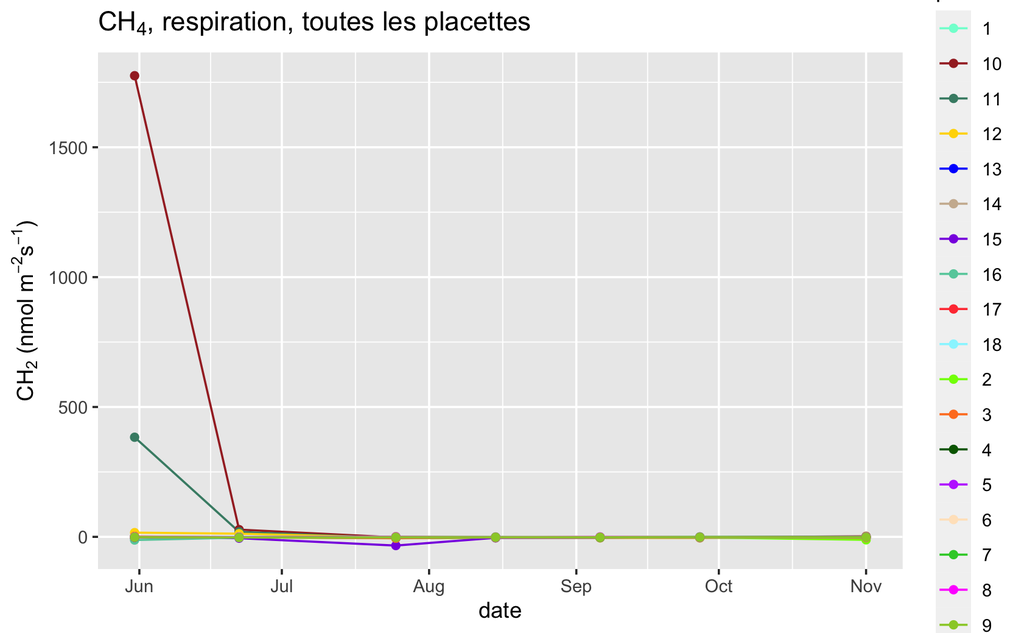

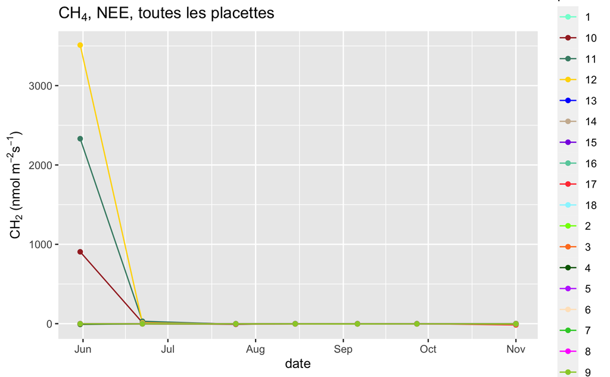

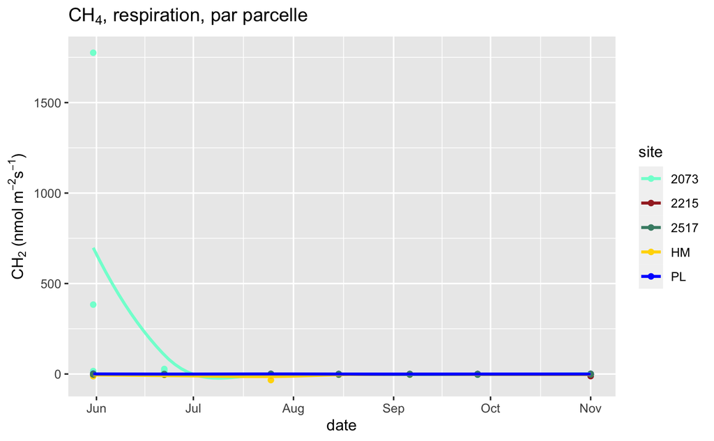

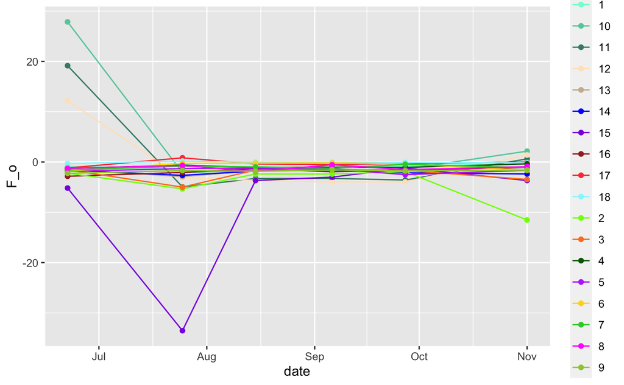

Taux très faible voir négatif de ch4, dû à la profondeur de nappe trop importante. Les emissions ont lieu sur les sites submergés.

le pic negatif correspond au haut marais. Le niveau de nappe est trop bas pour la production de ch4 mais les methanotrophes sont toujours actifs